# Ford GoBike System Data

## Member Gender vs Duration of Trip(sec)

Graphic shows that duration of trip distribution regarding to genders. Duration of trip is quite less for man gender but it is quite similar for female and others gender

```
Text(0.5,1,'Member Gender vs Duration of Trip(sec)')
```

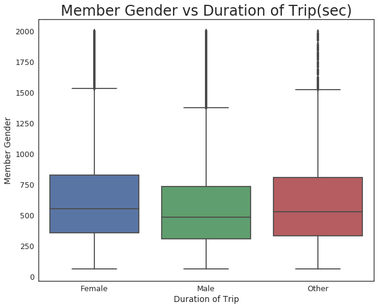

```python
sb.boxplot(x="member_gender", y="duration_sec", data=majority)
plt.xlabel('Duration of Trip')
plt.ylabel('Member Gender');
plt.title('Member Gender vs Duration of Trip(sec)',fontsize=24)
```

## Duration of Trip vs User Type

Graphic shows that customers have more duration of trip than subscribers. Interesting! Is it because it was their first experience and they wanted to try more?

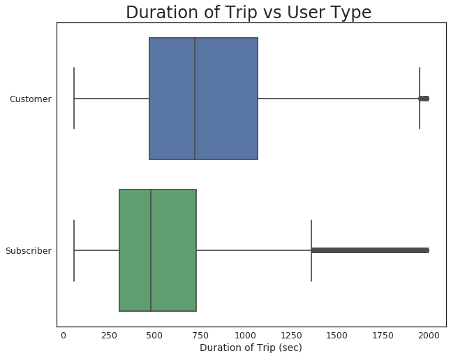

```python
majority = df_clean[df_clean['duration_sec'] < 2000]

sb.boxplot(data =majority , y='user_type', x='duration_sec')
plt.title('Duration of Trip vs User Type ',fontsize=24)
plt.xlabel('Duration of Trip (sec)')
plt.ylabel('');
```

## Duration Of Trip Per Day

Duration of trip in seconds is higher on Saturday and Sunday. Monday is most popular day in week days.

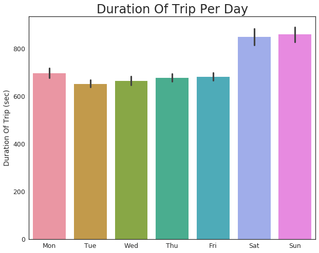

```python
order=['Mon', 'Tue','Wed','Thu','Fri','Sat','Sun']

ax=sb.barplot(data = df_clean , x = 'trip_day' , y='duration_sec', order=order)
plt.title('Duration Of Trip Per Day', fontsize=24)
plt.xlabel('')
plt.ylabel('Duration Of Trip (sec)');
```

## Duration of Trip Per Day Period

Graphic shows that people prefered to ride more at evening and morning.

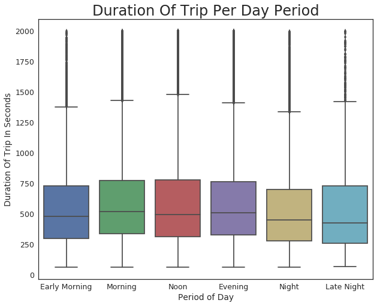

```python
sb.boxplot(data=majority, x='period', y='duration_sec', order=['Early Morning', 'Morning','Noon','Evening','Night','Late Night']);
plt.title('Duration Of Trip Per Day Period', fontsize=24)
plt.xlabel('Period of Day')
plt.ylabel('Duration Of Trip In Seconds');
```